# Linear Mixed Models (LMMs) - Model Comparisons

Joshua F. Wiley - updated for 2021 by Michelle Byrne

2021-05-24

These are the `R` packages we will use.

```r
options(digits = 5)

library(data.table)
library(JWileymisc)
library(extraoperators)
library(lme4)
library(lmerTest)
library(multilevelTools)
library(visreg)
```

```r
library(ggplot2)
library(ggpubr)
library(haven)
## load data collection exercise data
## merged is a a merged long dataset of baseline and daily
dm <- as.data.table(read_sav("[2021] PSY4210 merged.sav"))

## Remind R which of our variables are factors

dm[, sex := factor(
  sex,
  levels = c(1,2),
  labels = c("male", "female"))]

dm[, relsta := factor(
  relsta, levels = c(1,2,3),
  labels = c("single", "in a committed exclusive relationship", "in a committed nonexclusive relationship"))]
```

# 1 Comparing Models

For many statistical models, including LMMs, it can be informative to compare different models. Comparing different models can be used in lots of different ways. Here are some examples, although they are not meant to be exhaustive.

- Evaluate which of two (or more) models provides the best fit to the data
- Evaluate / compare how the results for a particular predictor(s) of interest change across two (or more) models
- Calculate the significance of multiple predictors
- Calculate effect sizes for one or multiple predictors

We will look at examples of the different uses of model comparisons in this topic.

Just as there are many different kinds of models we can fit, even with LMMs (e.g., with or without random slopes, etc.), so to there are many different kinds and purposes for different model comparisons.

To begin with, let’s imagine we are just trying to compare two models: Model A and Model B. We can broadly classify the type of comparison based on whether Model A and B are nested or non-nested models. We will talk about what these mean next.

## 1.1 Nested Models

Models are considered nested when one model is a restricted or constrained version of another model. For example, suppose that **Model A** predicts mood from stress and loneliness whereas **Model B** predicts mood from loneliness only. Written as a formula, these could be:

$$ModelA: mood_{ij} = b_{0j} + b1 * loneliness_j + b2 * stress_{ij} + \varepsilon_{ij}$$

and

$$ModelB: mood_{ij} = b_{0j} + b1 * loneliness_j + 0 * stress_{ij} + \varepsilon_{ij}$$

In **Model B**, I purposely used $0 * stress_{ij}$ to highlight that when a predictor is left out of a model, it is the same as fixing (sometimes also called constraining) the coefficient ($b2$ in this case) to be exactly 0. In this case, we would say that **Model B** is nested within **Model A**. In other words, **Model A** contains every predictor and parameter in **Model B** plus more.

This idea is similar to the idea of nested data used in LMMs, but the difference is that we are not talking about observations or data, rather we are talking about the parameters of a model.

To summarize, briefly, we say that **Model B** is *nested* within **Model A** if:

- setting one or more parameters in **Model A** to 0 yields the same model as **Model B**.
- both models use the same data, have the same number of observations, etc. Even if the same dataset is used in `R`, this does not guarantee the same data are used because if additional predictors are included in **Model A** and these extra predictors have some missing data, by default `R` would drop the missing data and result in a subset of cases being used for **Model A** than for **Model B**

If two models are nested, then we have the most options in terms of comparing the two models. For example, we can evaluate whether **Model A** is a statistically significantly better fit than is **Model B** using a Likelihood Ratio Test (LRT).

https://en.wikipedia.org/wiki/Likelihood-ratio_test

We can compare the fit of each model and use the difference in fit to derive effect sizes. We also can attribute any differences in the two models to the parameter(s) that have been constrainted to 0 in **Model B** from **Model A**.

A simple definition of the LRT test statistic, $\lambda$ is based on two times the difference in the log likelihoods.

$$\lambda = -2 * (LL_B - LL_A)$$

You may wonder why the likelihood *ratio* test can be conducted by taking the difference in the log likelihoods. It is because the log of a ratio is the same as the difference in the logs of the numerator and denominator.

$$log_{e}\left(\frac{6}{2}\right) = log_{e}(6) - log_{e}(2)$$

which we can confirm is true in `R`:

```r
## log of ratio
log(6/2)
```

```
## [1] 1.0986
```

```r
## difference in logs
log(6) - log(2)
```

```
## [1] 1.0986
```

If the null hypothesis of no difference is true in the population, then $\lambda$ will follow a chi-squared distribution with degrees of freedom equal to the number of parameters constrained to 0 in **Model B** from **Model A**, the difference in degrees of freedom used for each model, that is:

$$\lambda \sim \chi^2(DF_A - DF_B)$$

Thus we often use a chi-square distribution in the LRT to look up the p-value. Finally, note that because LRTs are based on the log likelihoods (LL) from a model, we need true log likelihoods for the LRT to be valid. Therefore, we cannot use restricted maximum likelihood, we need to use maximum likelihood estimation.

### 1.1.1 Nested Models in `R`

To see the idea of nested models and the LRT in action, let’s examine a concrete example in `R`. Here are two LMMs corresponding to **Model A** and **Model B** formula we wrote previously. We can see in the `R` code that the models are nested, the only difference is `stress`. We set `REML = FALSE` to get maximum likelihood estimates so that we get true log likelihoods. We also need to confirm that the two models are based on the same number of observations. We can extract just this information in `R` using the `nobs()` function. This lets us confirm that the two models are fitted to the same data. For example, if stress had some missing data that was not missing loneliness or mood, it could be that **Model A** is based on fewer observations than **Model B**.

```r
modela <- lmer(dMood ~ loneliness + dStress + (1 | ID), data = dm, REML = FALSE)
modelb <- lmer(dMood ~ loneliness + (1 | ID), data = dm, REML = FALSE)

nobs(modela)
```

```
## [1] 283
```

```r
nobs(modelb)
```

```
## [1] 283
```

In this case, we can see that the number of observations are identical. Now we can find the log likelihoods of both models by using the `logLik()` function.

```r
logLik(modela)
```

```
## 'log Lik.' -396.81 (df=5)
```

```r
logLik(modelb)
```

```
## 'log Lik.' -432.79 (df=4)
```

Now we have the log likelihoods (LL) of each model and the degrees of freedom from both models. From this, we can calculate $\lambda$ and then look up the p-value for a chi-square distribution with $\lambda$ and 1 degree of freedom (1 is the difference in degrees of freedom between Model A and B). To get the p-value from a chi-square, we use the `pchisq()` function.

```r
## lambda
-2 * (-432.79 - -396.81)
```

```
## [1] 71.96
```

```r
## p-value from a chi-square
pchisq(71.96, df = 1, lower.tail = FALSE)
```

```
## [1] 2.196e-17
```

In practice, we do not need to do these steps by hand, we can get a test of two nested models in `R` using the `anova()` function (which in this case is not actually analyzing the variance really). We use the `anova()` function with `test = "LRT"` to get a likelihood ratio test.

```r
anova(modela, modelb, test = "LRT")
```

```
## Data: dm
## Models:
## modelb: dMood ~ loneliness + (1 | ID)
## modela: dMood ~ loneliness + dStress + (1 | ID)
##        Df AIC BIC logLik deviance Chisq Chi Df Pr(>Chisq)
## modelb  4 874 888   -433      866
## modela  5 804 822   -397      794    72      1     <2e-16 ***
## ---
## Signif. codes:  0 '***' 0.001 '**' 0.01 '*' 0.05 '.' 0.1 ' ' 1
```

If you compare the chi-square value, degrees of freedom and p-value, you’ll see that they basically match what we calculated by hand. The small differences are due to rounding (`R` will use more decimals of precision whereas we only used two decimals).

In this simple case, we are only testing a single parameter, the fixed regression coefficient for stress, because that is the only parameter that differs between **Model A** and **Model B**. Thus in this case, it would be easier to rely on the t-test we get from a summary of the model.

```r
summary(modela)
```

```
## Linear mixed model fit by maximum likelihood . t-tests use Satterthwaite's
##   method [lmerModLmerTest]
## Formula: dMood ~ loneliness + dStress + (1 | ID)
##    Data: dm
##
##      AIC      BIC   logLik deviance df.resid
##    803.6    821.8   -396.8    793.6      278
##
## Scaled residuals:
##    Min     1Q Median     3Q    Max
## -2.935 -0.665  0.145  0.656  2.163
##
## Random effects:
##  Groups   Name        Variance Std.Dev.
##  ID       (Intercept) 0.106    0.326
##  Residual             0.875    0.936
## Number of obs: 283, groups:  ID, 88
##
## Fixed effects:
##             Estimate Std. Error       df t value Pr(>|t|)
## (Intercept)   7.5359     0.2862  93.3199   26.33  < 2e-16 ***
## loneliness   -0.4935     0.1167  73.2663   -4.23  6.7e-05 ***
## dStress      -0.4132     0.0446 241.5678   -9.26  < 2e-16 ***
## ---
## Signif. codes:  0 '***' 0.001 '**' 0.01 '*' 0.05 '.' 0.1 ' ' 1
##
## Correlation of Fixed Effects:
##            (Intr) lnlnss
## loneliness -0.740
## dStress    -0.472 -0.197
```

In this instance, the LRT and the t-test actually yield equivalent p-values, 2e-16, however, this does not have to be. The LRT is based on slightly different theory than the t-test and the t-test uses approximate degrees of freedom for the t-distribution based on the Satterthwaite method, whereas the LRT does not directly incorporate the sample size in the same way. The two methods will be assymptotically equivalent (at very large sample sizes) but can differ, particularly for smaller samples.

In practice, we wouldn’t usually use a LRT to evaluate whether a single model parameter is statistically significant. The benefit of (nested) model comparisons is that it allows us to compare two models. Those models can be quite different.

Here are another two models, this time they differ by two predictors, energy and sex. The LRT now tests whether the addition of energy and sex results in significantly better fit for **Model A** than **Model B**.

```r
modela <- lmer(dMood ~ loneliness + stress + dEnergy + sex + (1 | ID),
               data = dm, REML = FALSE)
modelb <- lmer(dMood ~ loneliness + stress + (1 | ID), data = dm,
               REML = FALSE)

nobs(modela)
```

```
## [1] 283
```

```r
nobs(modelb)
```

```
## [1] 283
```

```r
anova(modela, modelb, test = "LRT")
```

```
## Data: dm
## Models:
## modelb: dMood ~ loneliness + stress + (1 | ID)
## modela: dMood ~ loneliness + stress + dEnergy + sex + (1 | ID)
##        Df AIC BIC logLik deviance Chisq Chi Df Pr(>Chisq)
## modelb  5 871 889   -430      861
## modela  7 771 797   -378      757   104      2     <2e-16 ***
## ---
## Signif. codes:  0 '***' 0.001 '**' 0.01 '*' 0.05 '.' 0.1 ' ' 1
```

In this case, we can see from the significant p-value that **Model A** is a significantly better fit to the data than is **Model B**. Note that LRTs are only appropriate when the models are nested. We cannot use LRTs for non-nested models.

In nested models, the more complex model is often called the “Full” model and the simpler model the “Reduced” or “Restricted” version of the Full model.

## 1.2 Non Nested Models

Models are considered non nested when one model is not strictly a constrained version of a more complex model. For example, suppose that **Model A** predicts mood from loneliness and stress whereas **Model B** predicts mood from loneliness and sex. Written as a formula, these could be:

$$ModelA: mood_{ij} = b_{0j} + b1 * loneliness_j + b2 * stress_{ij} + \varepsilon_{ij}$$

and

$$ModelB: mood_{ij} = b_{0j} + b1 * loneliness_j + b2 * sex_j + 0 * stress_{ij} + \varepsilon_{ij}$$

Although **Model B** does have loneliness which also is present in **Model A** and it has restricted stress to be 0, it has another addition, sex, which is not in **Model A**. In this case, the two models are not nested. In this case, although we could fit both models and they are both on the same number of observations, so the outcome is the same in both models, the models are not nested. Although we can still ask `R` to conduct a LRT, this LRT is not valid. It is shown here to highlight that you as the analyst are responsible for determining whether your two models are nested or not and therefore deciding whether a LRT is an appropriate way to evaluate whether the models are significantly different from each other, or not.

```r
modela <- lmer(dMood ~ loneliness + dStress + (1 | ID),
               data = dm, REML = FALSE)
modelb <- lmer(dMood ~ loneliness + sex + (1 | ID), data = dm,
               REML = FALSE)

nobs(modela)
```

```
## [1] 283
```

```r
nobs(modelb)
```

```
## [1] 283
```

```r
## this is NOT appropriate LRT
anova(modela, modelb, test = "LRT")
```

```
## Data: dm
## Models:
## modela: dMood ~ loneliness + dStress + (1 | ID)
## modelb: dMood ~ loneliness + sex + (1 | ID)
##        Df AIC BIC logLik deviance Chisq Chi Df Pr(>Chisq)
## modela  5 804 822   -397      794
## modelb  5 876 894   -433      866     0      0          1
```

Although we cannot conduct a LRT on non nested models, it *is* still useful to compare the fit of non-nested models. For example, if one is a much better fit than another model, that may suggest one set of predictors is superior or can be used to evaluate competing hypotheses (e.g., Theory 1 says that stress and family history are the most important predictors of mood and Theory 2 says that age and sleep are the best predictors of mood — these two theories are competing, not nested versions of each other).

We cannot use LRTs to compare non nested models, but we can use other measures, including performance measures such as variance explained or model accuracy and information criterion. We will talk about information criterion next.

## 1.3 Information Criterion

Two common information criterion are:

- AIC: the Akaike Information Criterion (AIC)

  https://en.wikipedia.org/wiki/Akaike_information_criterion
- BIC: the Bayesian Information Criterion (BIC) also sometimes called the Schwarz Information Criterion

  https://en.wikipedia.org/wiki/Bayesian_information_criterion

Both the AIC and BIC are calculated based primarily on the log likelihood, LL, of a model. One way of thinking about these information criterion is that you could think about models being a way of approximating reality. Suppose you have two models that both generate approximations (predictions) of reality. The model whose predictions are closer to the observed data will have a higher LL. The LL can be used as a *relative* measure of model fit. LL **is not** an absolute measure of fit. That is, we do not interpret a specific LL value as indicating “good” fit. Only which of a set of (all potentially bad) models is the best.

However, there is a limitation with using LL alone. The LL will always stay the same or increase as additional predictors / parameters are added to the model. Thus if we use the LL alone, out of a set of competing models, we would virtually always pick the more complex models. To address this, we need to incorporate some penalty for the complexity of a model, so that to choose a more complex over simpler model as the “best” it has to improve the LL *enough*.

The AIC and BIC are very similar except that they use different penalties for model complexity (technically they are derived from rather different theoretical foundations, but for practical purposes they are similar other than the complexity penalties).

A common way of defining model complexity is based on the number of estimated model parameters, $k$. For example, consider the following simple linear regression for $n$ different observations:

$$\begin{align}
\eta_{i} &= b_0 + b_1 * x_i\\
y_i &\sim \mathcal{N}(\eta_i, \sigma_{\varepsilon_i})\\
\end{align}$$

The parameters are:

$$b_0, b_1, \sigma_{\varepsilon_i}$$

so $k = 3$.

The equations for AIC and BIC are quite easy to follow and looking at them helps understand where they are similar and different.

$$\begin{align}
AIC &= 2 * k - 2 * LL \\
BIC &= log_{e}(n) * k - 2 * LL \\
\end{align}$$

$n$ is the number of observations included in the model and $LL$ is the log likelihood, where higher values indicate a better fitting model. These equations highlight that the only difference between the AIC and BIC is whether the number of parameters in the model, $k$ are multiplied by $2$ (AIC) or $log_{e}(n)$. Thus, the AIC and BIC will be identical if:

$$\begin{align}
log_{e}(n) &= 2 \\
n &= e^2 \approx 7.39 \\
\end{align}$$

If $n < e^2 \approx 7.39$ then the BIC will have a weaker penalty based on the number of parameters, $k$, than the AIC. If $n > e^2 \approx 7.39$ then the BIC will have a stronger penalty based on the number of parameters, $k$, than the AIC. Functionally, a stronger penalty on the number of parameters means that a particular information criterion will tend to favor more parsimonious (less complex) models. Thus, for all but the tiniest of sample sizes ($\approx 7.39$) the BIC will have a stronger penalty on model complexity and so will favor relatively more parsimonious models than will AIC.

For both AIC and BIC, the *relatively* better model of those compared is the model with the lower value (i.e., lower = better for both AIC and BIC).

**There is no “right” or “wrong” information criterion to use.** People use both the AIC and/or the BIC. If both AIC and BIC suggest the same model is the “best” there is no ambiguity. Sometimes the AIC and BIC disagree regarding which model is the best. In these cases one must pick which information criterion to go with. Both criterion require that the number of observations, $n$, be larger than the number of parameters, $k$ for them to operate well.

A benefit of the AIC and BIC is that both can be used to compare non nested models and they also can be used to compare nested models. It is relatively common to use AIC and/or BIC to “choose” amongst a set of possible models.

In `R` we can usually calculate AIC and BIC using the functions, `AIC()` and `BIC()`. Here we will calculate the AIC and BIC for our two models.

```r
AIC(modela, modelb)
```

```
##        df    AIC
## modela  5 803.62
## modelb  5 875.56
```

```r
BIC(modela, modelb)
```

```
##        df    BIC
## modela  5 821.85
## modelb  5 893.78
```

In this case, both the AIC and BIC are lower for **Model A** than for **Model B**, indicating that **Model A** is the optimal of those two models. Again, the relative interpretation is important. We cannot conclude that **Model A** is a “good” model, only that it is better than **Model B**.

## 1.4 Model Selection

Integrating what we have learned about LRT for nested models and AIC/BIC for nested or non nested models, we can compare across several models to select the best model.

First, we fit a series of models. In all cases, mood is the outcome. First we have an intercept only model (m0), an unconditional model, as a baseline reference. This is helpful as all the fit indices are relative. Then we fit polynomials of stress with degree 1 (linear; m1); degree 2 (quadratic; m2); degree 3 (cubic; m3). **If you are not familiar with polynomials, please see the extra section at the end of this lecture now.** We fit different degree polynomials of stress using the `poly()` function in `R`. Finally we fit a competing model, maybe a linear effect of energy is a better predictor of mood than stress.

Next, we check that all the observations are identical across models. **If the observations were not the same across models, we would need to create a new dataset that had any missing data on any variable used in any of the models excluded.** This is a critical step if needed, because LRTs and AIC and BIC are only valid if based on the same data.

```r
dm[, dStress := as.numeric(dStress)]
dm[, dMood := as.numeric(dMood)]

m0 <- lmer(dMood ~ 1 + (1 | ID), data = dm, REML = FALSE)
m1 <- lmer(dMood ~ poly(dStress, 1) + (1 | ID), data = dm, REML = FALSE)
m2 <- lmer(dMood ~ poly(dStress, 2) + (1 | ID), data = dm, REML = FALSE)
m3 <- lmer(dMood ~ poly(dStress, 3) + (1 | ID), data = dm, REML = FALSE)
malt <- lmer(dMood ~ dEnergy + (1 | ID), data = dm, REML = FALSE)

## check all the observations are the same
nobs(m0)
```

```
## [1] 283
```

```r
nobs(m1)
```

```
## [1] 283
```

```r
nobs(m2)
```

```
## [1] 283
```

```r
nobs(m3)
```

```
## [1] 283
```

```r
nobs(malt)
```

```
## [1] 283
```

Now we can see which model is the best fit. For the nested models (m0 - m3) we can use LRTs. Technically, m0 also is nested in malt, so we can use a LRT for that too. We cannot use a LRT for, say, m1 and malt as those models are not nested. We can use AIC and BIC for all models, though. Note that with multiple models, the `anova()` function is doing sequential LRT tests (e.g., m0 vs m1; m1 vs m2, etc.) not all compared to one model. If you want two specific models compared, specify just two.

```r
#### LRTs for nested models ####

## two specific comparisons
anova(m0, m3, test = "LRT")
```

```
## Data: dm
## Models:
## m0: dMood ~ 1 + (1 | ID)
## m3: dMood ~ poly(dStress, 3) + (1 | ID)
##    Df AIC BIC logLik deviance Chisq Chi Df Pr(>Chisq)
## m0  3 891 902   -442      885
## m3  6 820 842   -404      808    77      3     <2e-16 ***
## ---
## Signif. codes:  0 '***' 0.001 '**' 0.01 '*' 0.05 '.' 0.1 ' ' 1
```

```r
## sequential comparisons
anova(m0, m1, m2, m3, test = "LRT")
```

```
## Data: dm
## Models:
## m0: dMood ~ 1 + (1 | ID)
## m1: dMood ~ poly(dStress, 1) + (1 | ID)
## m2: dMood ~ poly(dStress, 2) + (1 | ID)
## m3: dMood ~ poly(dStress, 3) + (1 | ID)
##    Df AIC BIC logLik deviance Chisq Chi Df Pr(>Chisq)
## m0  3 891 902   -442      885
## m1  4 817 832   -405      809 75.42      1     <2e-16 ***
## m2  5 819 837   -404      809  0.56      1       0.46
## m3  6 820 842   -404      808  1.02      1       0.31
## ---
## Signif. codes:  0 '***' 0.001 '**' 0.01 '*' 0.05 '.' 0.1 ' ' 1
```

```r
anova(m0, malt, test = "LRT")
```

```
## Data: dm
## Models:
## m0: dMood ~ 1 + (1 | ID)
## malt: dMood ~ dEnergy + (1 | ID)
##      Df AIC BIC logLik deviance Chisq Chi Df Pr(>Chisq)
## m0    3 891 902   -442      885
## malt  4 783 797   -387      775   110      1     <2e-16 ***
## ---
## Signif. codes:  0 '***' 0.001 '**' 0.01 '*' 0.05 '.' 0.1 ' ' 1
```

```r
## AIC and BIC for nested and non nested models
AIC(m0, m1, m2, m3, malt)
```

```
##      df    AIC
## m0    3 890.91
## m1    4 817.49
## m2    5 818.94
## m3    6 819.92
## malt  4 782.63
```

```r
BIC(m0, m1, m2, m3, malt)
```

```
##      df    BIC
## m0    3 901.85
## m1    4 832.07
## m2    5 837.16
## m3    6 841.79
## malt  4 797.21
```

From the LRT we can see that m3 is significantly better fit than m0. Looking at the sequential tests, however, m2 is no better than m1 and m3 is no better than m2, which might suggest m1 is the best model. If we look at the AIC values, for the models with stress (m1,m2,m3), AIC selects m1 as the best model (by 1.45 compared to m2, very close). BIC also selects m1 over m2. However, both AIC and BIC indicate that the alternate model (malt) is the best of all the models evaluated, suggesting that linear energy is a better predictor of mood than is linear, quadratic, or cubic polynomials of stress.

If we were picking a stress model only, we would pick the linear (m1) model, because it is best on all indices (LRT, AIC, BIC). If we were willing to pick energy over stress, we would clearly go with energy.

In addition to testing fixed effects, these same methods can be used to test random effects. Here we will fit a new model, m4, that includes a random slope of stress and the correlation between the random intercept and stress slope. Then we compare the linear stress with random slope (m4), linear stress without random slope (m1) and intercept only model (m0). Please note that m4 did not converge, so normally we would simplify our model but we don’t want to remove the random slope of stress for demonstration purposes - so in this case we will have to remember not to “trust” our results for m4.

```r
m4 <- lmer(dMood ~ dStress + (1 + dStress | ID), data = dm, REML = FALSE)
## check all the observations are the same
nobs(m0)
```

```
## [1] 283
```

```r
nobs(m1)
```

```
## [1] 283
```

```r
nobs(m4)
```

```
## [1] 283
```

```r
anova(m0, m1, test = "LRT")
```

```
## Data: dm
## Models:
## m0: dMood ~ 1 + (1 | ID)
## m1: dMood ~ poly(dStress, 1) + (1 | ID)
##    Df AIC BIC logLik deviance Chisq Chi Df Pr(>Chisq)
## m0  3 891 902   -442      885
## m1  4 817 832   -405      809  75.4      1     <2e-16 ***
## ---
## Signif. codes:  0 '***' 0.001 '**' 0.01 '*' 0.05 '.' 0.1 ' ' 1
```

```r
anova(m1, m4, test = "LRT")
```

```
## Data: dm
## Models:
## m1: dMood ~ poly(dStress, 1) + (1 | ID)
## m4: dMood ~ dStress + (1 + dStress | ID)
##    Df AIC BIC logLik deviance Chisq Chi Df Pr(>Chisq)
## m1  4 817 832   -405      809
## m4  6 812 834   -400      800  9.22      2       0.01 **
## ---
## Signif. codes:  0 '***' 0.001 '**' 0.01 '*' 0.05 '.' 0.1 ' ' 1
```

```r
anova(m0, m4, test = "LRT")
```

```
## Data: dm
## Models:
## m0: dMood ~ 1 + (1 | ID)
## m4: dMood ~ dStress + (1 + dStress | ID)
##    Df AIC BIC logLik deviance Chisq Chi Df Pr(>Chisq)
## m0  3 891 902   -442      885
## m4  6 812 834   -400      800  84.6      3     <2e-16 ***
## ---
## Signif. codes:  0 '***' 0.001 '**' 0.01 '*' 0.05 '.' 0.1 ' ' 1
```

```r
AIC(m0, m1, m4)
```

```
##    df    AIC
## m0  3 890.91
## m1  4 817.49
## m4  6 812.27
```

```r
BIC(m0, m1, m4)
```

```
##    df    BIC
## m0  3 901.85
## m1  4 832.07
## m4  6 834.14
```

From these tests we can conclude several things. Firstly adding a linear trend of stress as a fixed effect is signfiicantly better than the intercept only model. Secondly (if our model had converged), adding a random slope of stress and correlation of the random slope and intercept is also significantly better than the fixed linear effect of stress model. Thirdly, the model with stress as both a fixed and random slope is signficantly better than the intercept only model (m4 vs m0 is kind of an omnibus test of the effect of adding stress as both a fixed and random slope into the model).

Finally, AIC favours m4 and and BIC favours m1 over the other models, and since m4 did not converge, suggests that m1 is the best balance of complexity and model fit (and certainly better than m0).

The main point of this final exercise is to show how you can use LRTs and AIC and BIC to evaluate whether random effects “help” a model fit.

# 2 Effect Sizes

As with other statistical models, relying solely on statistical significance is limiting as it ignores the magnitude of an effect.

Simple $R^2$ measures of variance accounted for are problematic, however, recently several approaches have been put forward.

To understand these measures, let’s go back to a relatively simple LMM with a fixed effect predictor and a random intercept only.

$$y_{ij} = b_{0j} + b_1 * x_j + \varepsilon_{ij}$$

substituting we get:

$$y_{ij} = \gamma_{00} + u_{0j} + b_1 * x_j + \varepsilon_{ij}$$

and re-arranging slightly, we can break the model down into essentially three “parts”:

$$y_{ij} = \overbrace{\gamma_{00} + b_1 * x_j}^\text{fixed} + \underbrace{u_{0j}}_\text{random} + \overbrace{\varepsilon_{ij}}^{residual}$$

For each of these three parts, we can calculate the variance associated with them. First the variance of the fixed effects portion of the model:

$$\sigma^{2}_{fixed} = Var(\gamma_{00} + b_1 * x_j)$$

Next the variance of the random effects part of the model, here the random intercept:

$$u_{0j} \sim \mathcal{N}(0, \sigma^{2}_{u_{0}})$$

Finally, the variance of the residuals (the unexplained part):

$$\varepsilon_{ij} \sim \mathcal{N}(0, \sigma^{2}_{\varepsilon})$$

Nakagawa and Schielzeth (2013; https://doi.org/10.1111/j.2041-210x.2012.00261.x) defined two variance explained measures defined based on these components as follows:

$$R^{2}_{LMM(m)} = \frac{\sigma^{2}_{fixed}}{\sigma^{2}_{fixed} +
\sigma^{2}_{u_{0}} + \sigma^{2}_{\varepsilon}}$$

and

$$R^{2}_{LMM(c)} = \frac{\sigma^{2}_{fixed} + \sigma^{2}_{u_{0}}}{\sigma^{2}_{fixed} +
\sigma^{2}_{u_{0}} + \sigma^{2}_{\varepsilon}}$$

As it is difficult to write $R^{2}_{LMM(m)}$, I refer to this as the Marginal R2. It captures the proportion of the total variance attributable to the fixed effects portion of the model.

Likewise, $R^{2}_{LMM(c)}$ is referred to as the Conditional R2. It captures the proportion of the total variance attributable to both the fixed and random effects portion of the model (i.e., it only excludes the residual variance).

The Conditional R2 essentially measures the total proportion of variability explainable by the model. The Marginal R2 measures the total proportion of variability explainable only by the fixed effects, the ‘average’ or marginal effect in the population. Both are useful in different circumstances. Because the Conditional R2 incorporates random effects, it is **not** a measure of how much variance we could predict in a new data. For example if we had a LMM built and then applied the model to data on a new patient who came to a clinic, without their data we will not know what their random effects should be, so we could only apply the average effects, the fixed effects. Thus, the Marginal R2 can give us a sense of how much variance we might explain using only the averages from our model and how much we might explain if we had data on someone new. The Conditional R2 uses both the fixed and random effects and can tell us how much variance, essentially in our own sample, our model is able to explain.

One caveat: it is technically possible for the Marginal R2 to **decrease** when more predictors are added to the model. This does not happen in linear regression, but it can happen with the Marginal R2. It generally does not happen, but it can. This is simply a limitation of how LMMs are estimated.

Also note that if you have an intercept only model, that is a model with only a fixed and a random intercept, there will be no variability associated with the fixed effects (since there is only an intercept and it does not vary) and in this special case, the Conditional R2 is identical to the ICC.

Although we looked at the formula for Marginal R2 and Conditional R2 from a LMM with only a random intercept and no other random effects, Johnson (2014; https://dx.doi.org/10.1111/2041-210X.12225) has shown they can be extended to random slope models. Although additional random components are included, the interpretation of the Marginal R2 as being the proportion of total variance attributable to fixed effects only and Conditional R2 being the proportion of total variance attributable to the model, the fixed and random effects together, remains the same.

In `R`, we can calculate these measures using the `R2()` function. To start with, let’s look at an intercept only model and compare the R2 results to the ICC.

```r
m0b <- lmer(dMood ~  1 + (1 | ID), data = dm)

summary(m0b)
```

```
## Linear mixed model fit by REML. t-tests use Satterthwaite's method [
## lmerModLmerTest]
## Formula: dMood ~ 1 + (1 | ID)
##    Data: dm
##
## REML criterion at convergence: 887.7
##
## Scaled residuals:
##     Min      1Q  Median      3Q     Max
## -2.6877 -0.5388  0.0648  0.6891  2.3113
##
## Random effects:
##  Groups   Name        Variance Std.Dev.
##  ID       (Intercept) 0.473    0.688
##  Residual             1.025    1.013
## Number of obs: 283, groups:  ID, 88
##
## Fixed effects:
##             Estimate Std. Error      df t value Pr(>|t|)
## (Intercept)   4.7974     0.0986 83.2007    48.7   <2e-16 ***
## ---
## Signif. codes:  0 '***' 0.001 '**' 0.01 '*' 0.05 '.' 0.1 ' ' 1
```

```r
R2(m0b)
```

```
##    MarginalR2 ConditionalR2
##        0.0000        0.3159
```

```r
iccMixed("dMood", "ID", data = dm)
```

```
##         Var   Sigma    ICC
## 1:       ID 0.47345 0.3159
## 2: Residual 1.02526 0.6841
```

Here we can see that the Marginal R2 is 0, which makes sense as we have no fixed effects predictors, only the fixed effect intercept, which does not vary (because it is *fixed*). The Conditional R2 is equal to the ICC, because it captures the proportion of total variance attributable to the fixed and random effects, but the fixed effects variance is 0, so its just the variance of the random intercept over the total variance, which is the equation for the ICC.

Now let’s look at a more complex example. Here we use the model with a linear stress trend predicting mood as a fixed effect with a random intercept.

```r
summary(m1)
```

```
## Linear mixed model fit by maximum likelihood . t-tests use Satterthwaite's
##   method [lmerModLmerTest]
## Formula: dMood ~ poly(dStress, 1) + (1 | ID)
##    Data: dm
##
##      AIC      BIC   logLik deviance df.resid
##    817.5    832.1   -404.7    809.5      279
##
## Scaled residuals:
##     Min      1Q  Median      3Q     Max
## -2.9714 -0.6106  0.0629  0.6310  2.1327
##
## Random effects:
##  Groups   Name        Variance Std.Dev.
##  ID       (Intercept) 0.196    0.442
##  Residual             0.870    0.933
## Number of obs: 283, groups:  ID, 88
##
## Fixed effects:
##                  Estimate Std. Error       df t value Pr(>|t|)
## (Intercept)        4.7814     0.0754  75.8993   63.43   <2e-16 ***
## poly(dStress, 1) -10.3837     1.0834 255.9435   -9.58   <2e-16 ***
## ---
## Signif. codes:  0 '***' 0.001 '**' 0.01 '*' 0.05 '.' 0.1 ' ' 1
##
## Correlation of Fixed Effects:
##             (Intr)
## ply(dStr,1) 0.012
```

```r
R2(m1)
```

```
##    MarginalR2 ConditionalR2
##       0.26339       0.39873
```

Here we can see that the fixed effect of stress explains about 26% of the variance in mood (Marginal R2). The model overall explains about 40% of the variance in mood (Conditional R2).

We can also calculate effect sizes that are equivalent to Cohen’s $f^2$ effect size. Recall that:

$$f^2 = \frac{R^2}{1 - R^2}$$

So we can define

$$f^2_{LMM(m)} = \frac{R^2_{LMM(m)}}{1 - R^2_{LMM(m)}}$$

and

$$f^2_{LMM(c)} = \frac{R^2_{LMM(c)}}{1 - R^2_{LMM(c)}}$$

which are a Marginal and Cnditional F2 effect size. We can get all of these and other model performance measures, like AIC and BIC using the `modelPerformance()` function.

```r
modelPerformance(m1)
```

```
## $Performance
##     Model Estimator N_Obs N_Groups    AIC    BIC      LL LLDF  Sigma MarginalR2
## 1: merMod        ML   283  ID (88) 817.49 832.07 -404.75    4 0.9326    0.26339
##    ConditionalR2 MarginalF2 ConditionalF2
## 1:       0.39873    0.35757       0.66314
##
## attr(,"class")
## [1] "modelPerformance.merMod" "modelPerformance"
```

# 3 Effect Sizes for Differences

Often we are interested in the effect size for a particular model parameter or a particular variable in our model. For example, we may want to know what is the unique effect size for stress predicting mood? The overall model effect sizes are not the right answer to this question. We need to calculate how much the model performance *changed* when just the parameter(s) of interest changed. That is, we need to compare two, nested models. For these, it is best to use ML, *not* REML. Here we will fit two models with m.a nested within m.ab. This way, we can ensure that the only difference between the two models is the addition of a fixed effect slope of stress.

```r
m.ab <- lmer(dMood ~ dStress + (1 | ID), data = dm, REML = FALSE)
m.a <- lmer(dMood ~ 1 + (1 | ID), data = dm, REML = FALSE)

nobs(m.ab)
```

```
## [1] 283
```

```r
nobs(m.a)
```

```
## [1] 283
```

Now we can define a specific effect size:

$$f^2 = \frac{R^2_{AB} - R^2_{A}}{1 - R^2_{AB}}$$

For simplicity, I am just writing the formula once, but we can calculate a Marginal F2 and Conditional F2 by using Marginal R2 or Conditional R2. The key here is in the top of the fraction: we calculate the unique variance explained by calculating the difference in variance explained between our two models. If the two models differ *only* by one parameter/predictor as in this case, then the effect size is for one specific predictor. However, we can use this to calculate an effect size for multiple parameters. Later, we will see some cases where we would care about this.

Let’s calculate this now for stress.

```r
R2(m.ab)
```

```
##    MarginalR2 ConditionalR2
##       0.26339       0.39873
```

```r
R2(m.a)
```

```
##    MarginalR2 ConditionalR2
##       0.00000       0.31161
```

```r
## Marginal F2 for stress
(.26339 - 0) / (1 - .26339)
```

```
## [1] 0.35757
```

```r
## Conditional F2 for stress
(.39873 - .31161) / (1 - .39873)
```

```
## [1] 0.14489
```

Let’s extend this. Suppose we added stress as both a fixed and random slope (ignore converge issue for now) and wanted to get the *overall* effect size for stress.

```r
m.abc <- lmer(dMood ~ dStress + (1 + dStress | ID), data = dm, REML = FALSE)
R2(m.abc)
```

```
##    MarginalR2 ConditionalR2
##       0.25934       0.45252
```

```r
R2(m.a)
```

```
##    MarginalR2 ConditionalR2
##       0.00000       0.31161
```

```r
## Marginal F2 for stress OVERALL (fixed + random slope vs intercept only)
(0.25934  - 0) / (1 - 0.25934)
```

```
## [1] 0.35015
```

```r
## Conditional F2 for stress OVERALL (fixed + random slope vs intercept only)
(0.45252 - .31161) / (1 - 0.45252)
```

```
## [1] 0.25738
```

We could also ask, how much does the effect size change when we added stress as a random slope on top of the model with stress as a fixed effect slope only?

```r
R2(m.abc)
```

```
##    MarginalR2 ConditionalR2
##       0.25934       0.45252
```

```r
R2(m.ab)
```

```
##    MarginalR2 ConditionalR2
##       0.26339       0.39873
```

```r
## Marginal F2 for random effect of stress
(0.25934 - 0.26339) / (1 - 0.25934)
```

```
## [1] -0.0054681
```

```r
## Conditional F2 for random effect of stress
(0.45252 - 0.39873) / (1 - 0.45252)
```

```
## [1] 0.09825
```

In this case, we get the (seemingly odd) negative value for the Marginal F2 and a small effect size for the Conditional F2.

According to Cohen’s (1988) guidelines, which should be treated as rough rules of thumb only:

*$f^2 \geq 0.02$ is small* $f^2 \geq 0.15$ is medium *$f^2 \geq 0.35$ is large

whether those cut offs well translate into LMMs and Marginal and Conditional F2 (which certainly was not the context Cohen would have imagined them being applied to) is unclear.

We could also use LRTs to test the overall (fixed + random) or random only effect of stress as these are nested models.

```r
## overall effect (fixed + random)
anova(m.a, m.abc, test = "LRT")
```

```
## Data: dm
## Models:
## m.a: dMood ~ 1 + (1 | ID)
## m.abc: dMood ~ dStress + (1 + dStress | ID)
##       Df AIC BIC logLik deviance Chisq Chi Df Pr(>Chisq)
## m.a    3 891 902   -442      885
## m.abc  6 812 834   -400      800  84.6      3     <2e-16 ***
## ---
## Signif. codes:  0 '***' 0.001 '**' 0.01 '*' 0.05 '.' 0.1 ' ' 1
```

```r
## random effect only
anova(m.ab, m.abc, test = "LRT")
```

```
## Data: dm
## Models:
## m.ab: dMood ~ dStress + (1 | ID)
## m.abc: dMood ~ dStress + (1 + dStress | ID)
##       Df AIC BIC logLik deviance Chisq Chi Df Pr(>Chisq)
## m.ab   4 817 832   -405      809
## m.abc  6 812 834   -400      800  9.22      2       0.01 **
## ---
## Signif. codes:  0 '***' 0.001 '**' 0.01 '*' 0.05 '.' 0.1 ' ' 1
```

Another point that is worth noting is that to get all of this information, we actually had to fit three different models and make various comparisons between all three of them. That is quite a bit of effort. If we had a model with multiple predictors, fitting three models to test each predictor would be a lot of effort. The `modelTest()` function actually does all of this for us basically. Let’s run it and then use `APAStyler()` to get some nicely formatted output.

```r
APAStyler(modelTest(m.abc))
```

```
##                           Term                     Est           Type
##  1:                (Intercept)  6.61*** [ 6.21,  7.01]  Fixed Effects
##  2:                    dStress -0.44*** [-0.54, -0.34]  Fixed Effects
##  3: cor_dStress.(Intercept)|ID                   -0.94 Random Effects
##  4:          sd_(Intercept)|ID                    0.63 Random Effects
##  5:              sd_dStress|ID                    0.23 Random Effects
##  6:                      sigma                    0.89 Random Effects
##  7:                   Model DF                       6  Overall Model
##  8:                 N (Groups)                 ID (88)  Overall Model
##  9:           N (Observations)                     283  Overall Model
## 10:                     logLik                 -400.14  Overall Model
## 11:                        AIC                  812.27  Overall Model
## 12:                        BIC                  834.14  Overall Model
## 13:                Marginal R2                    0.26  Overall Model
## 14:                Marginal F2                    0.35  Overall Model
## 15:             Conditional R2                    0.45  Overall Model
## 16:             Conditional F2                    0.83  Overall Model
## 17:   dStress (Fixed + Random)     0.35/0.26, p < .001   Effect Sizes
## 18:           dStress (Random)    -0.01/0.10, p = .010   Effect Sizes
```

Previously, we saw this output and only focused through the fixed and random effects. Now let’s look at some of the other output. We have the model AIC and BIC provided, which can be helpful for comparing between different models. We have the overall model Marginal and Conditional R2 and F2. We also have effect sizes and some p-values for labeled “Effect Sizes”. Specifically:

- dStress (Fixed + Random) - this contrasts the model with stress as a both a fixed and random effect to a model without stress as either a fixed or random effect (m.a vs m.abc in our previous work). The `Est` column lists the Marginal/Conditional F2, here Marginal = 0.35 and Conditional = 0.26. The p-value comes from a LRT comparing the two models. This p-value, p < .001, is the overall test of whether adding both the fixed and random slope of stress improves the LL of the model.
- dStress (Random) - this contrasts the model with stress as both a fixed and random effect to a model without stress as a random slope but with stress as a fixed effect (m.ab vs m.abc in our previous work). The `Est` column lists the Marginal/Conditional F2, here for a random effect only the marginal is not interesting but the Conditional F2 is useful. The p-value again comes from a LRT testing whether the addition of stress a a random slope significantly improves the LL. Although caution is always warranted on p-values for variances of random effects, it can be a helpful guide and the LRT is about the best possible p-value that can be computed (short of a bootstrapped one).

Thus, using `modelTest()` we can actually get by default a lot of the comparisons and effect sizes that we may be interested in and we can get effect size estimates *for specific predictors*. A test of stress only as a fixed effect is not included because it does not make sense to test the addition of a fixed effect onto a model with a random effect but no fixed effect.

`APAStyler()` can take a list of models as well, so its possible for even more comparisons. For example, we might wonder the impact of a covariate, say anxiety (anx).

```r
m.abcov <- update(m.abc, . ~ . + anx)

APAStyler(list(
  Unadjusted = modelTest(m.abc),
  Adjusted = modelTest(m.abcov)))
```

```
##                           Term              Unadjusted                Adjusted
##  1:                (Intercept)  6.61*** [ 6.21,  7.01]  6.85*** [ 6.31,  7.38]
##  2:                    dStress -0.44*** [-0.54, -0.34] -0.42*** [-0.53, -0.32]
##  3:                        anx                            -0.12 [-0.29,  0.06]
##  4: cor_dStress.(Intercept)|ID                   -0.94                   -0.94
##  5:          sd_(Intercept)|ID                    0.63                    0.61
##  6:              sd_dStress|ID                    0.23                    0.22
##  7:                      sigma                    0.89                    0.90
##  8:                   Model DF                       6                       7
##  9:                 N (Groups)                 ID (88)                 ID (88)
## 10:           N (Observations)                     283                     283
## 11:                     logLik                 -400.14                 -399.35
## 12:                        AIC                  812.27                  812.70
## 13:                        BIC                  834.14                  838.22
## 14:                Marginal R2                    0.26                    0.27
```

[output cut: 27 more lines]

Now we get all the estimates for stress as before but also those are repeated for the model with anxiety. We can see that anxiety (anx) has a basically 0 effect size either marginal or conditional. We can also see that both the AIC and BIC favor the unadjusted model and that the fixed effect coefficient and standard deviation for the random stress slope are basically unchanged with or without anx in the model.

## 3.1 Between Only Variables

So far for effect sizes, we were focused primarily on variables that differed both between and within person (stress). However, although the same strategy and effect sizes can be used for variables that vary **only** between people or **only** within person, what results we expect are a little different.

Also, although `modelTest()` uses the Wald method by default for confidence intervals, just as for the `confint()` function the method can be specified to pick what you want, such as profile likelihood.

Also note that in this case I am not comparing models so I will use the default REML estimation rather than pure ML.

```r
dm[, c("Bstress", "Wstress") := meanDeviations(dStress), by = ID]

m.between <- lmer(dMood ~ Bstress + (1 | ID), data = dm)

APAStyler(modelTest(m.between, method = "profile"),
  pcontrol = list(digits = 3, stars = FALSE, includeP = TRUE,
                  includeSign = TRUE, dropLeadingZero = TRUE))
```

```
## Computing profile confidence intervals ...
```

```
## Parameters and CIs are based on REML,
## but modelTests requires ML not REML fit for comparisons,
## and these are used in effect sizes. Refitting.
```

```
##                  Term                          Est           Type
##  1:       (Intercept)  6.96p < .001 [ 6.38,  7.54]  Fixed Effects
##  2:           Bstress -0.53p < .001 [-0.66, -0.39]  Fixed Effects
##  3: sd_(Intercept)|ID            0.39 [0.13, 0.56] Random Effects
##  4:             sigma            1.01 [0.92, 1.12] Random Effects
##  5:          Model DF                            4  Overall Model
##  6:        N (Groups)                      ID (88)  Overall Model
##  7:  N (Observations)                          283  Overall Model
##  8:            logLik                      -420.74  Overall Model
##  9:               AIC                       849.49  Overall Model
## 10:               BIC                       864.07  Overall Model
## 11:       Marginal R2                         0.21  Overall Model
## 12:       Marginal F2                         0.27  Overall Model
## 13:    Conditional R2                         0.31  Overall Model
## 14:    Conditional F2                         0.45  Overall Model
## 15:   Bstress (Fixed)          0.27/0.00, p < .001   Effect Sizes
```

In the output we can see that parameters and CIs were based on REML. However, the effect sizes are based on ML, because those are based off of model comparisons. First of all, we can see in the effect sizes for Bstress that the p-value is about the same from the p-value from the fixed effects - but sometimes it differs very slightly. This may be due either to minor differences between REML and ML estimation or due to one test being a t-test with approximate degrees of freedom. Here it is the same.

The Marginal F2 for Bstress indicates that it has a medium effect size. The conditional F2 is basically zero. This is not surprising as the addition of Bstress is not likely to improve the fit of the conditional model over the random intercept model. Individual differences in mean level of mood are already captured in the random intercept model, so for the conditional model, it will be very difficult for Bstress to actually improve the overall variance explained. Instead, Bstress is able to shift what was previously variance due to the random intercept to variance attributable to the fixed effects portion of the model. In terms of the equations:

$$R^{2}_{LMM(m)} = \frac{\sigma^{2}_{fixed}}{\sigma^{2}_{fixed} +
\sigma^{2}_{u_{0}} + \sigma^{2}_{\varepsilon}}$$

and

$$R^{2}_{LMM(c)} = \frac{\sigma^{2}_{fixed} + \sigma^{2}_{u_{0}}}{\sigma^{2}_{fixed} +
\sigma^{2}_{u_{0}} + \sigma^{2}_{\varepsilon}}$$

any gains in $\sigma^{2}_{fixed}$ will basically be matched by a decrease in $\sigma^{2}_{u_{0}}$, thus while the marginal variance explained increases, the conditional variance explained is more or less constant, so no change (0 effect size).

In summary, we can say that there is a significant, negative association between average stress and average mood (b [95% CI] = -0.53 [-0.66, -0.39], p < .001), with a medium effect size for the fixed effects, $f^2$ = .27. The pattern of results is that higher average stress was associated with lower average mood.

Because we do not expect a meaningful impact on the Conditional F2, I did not even mention it in the interpretation for a between only fixed effect predictor.

## 3.2 Within Only Variables

Here we have an example of a variable that **only** varies within, not between individuals. This is interpreted basically the same was as a variable that varies both between and within (like overall stress).

```r
m.within <- lmer(dMood ~ Wstress + (1 | ID), data = dm)
summary(lmer(dMood ~ 1 + (1 | ID), data = dm))
```

```
## Linear mixed model fit by REML. t-tests use Satterthwaite's method [
## lmerModLmerTest]
## Formula: dMood ~ 1 + (1 | ID)
##    Data: dm
##
## REML criterion at convergence: 887.7
##
## Scaled residuals:
##     Min      1Q  Median      3Q     Max
## -2.6877 -0.5388  0.0648  0.6891  2.3113
##
## Random effects:
##  Groups   Name        Variance Std.Dev.
##  ID       (Intercept) 0.473    0.688
##  Residual             1.025    1.013
## Number of obs: 283, groups:  ID, 88
##
## Fixed effects:
##             Estimate Std. Error      df t value Pr(>|t|)
## (Intercept)   4.7974     0.0986 83.2007    48.7   <2e-16 ***
## ---
## Signif. codes:  0 '***' 0.001 '**' 0.01 '*' 0.05 '.' 0.1 ' ' 1
```

```r
APAStyler(modelTest(m.within, method = "profile"),
  pcontrol = list(digits = 3, stars = FALSE, includeP = TRUE,
                  includeSign = TRUE, dropLeadingZero = TRUE))
```

```
## Computing profile confidence intervals ...
```

```
## Parameters and CIs are based on REML,
## but modelTests requires ML not REML fit for comparisons,
## and these are used in effect sizes. Refitting.
```

```
##                  Term                          Est           Type
##  1:       (Intercept)  4.80p < .001 [ 4.61,  4.99]  Fixed Effects
##  2:           Wstress -0.37p < .001 [-0.49, -0.25]  Fixed Effects
##  3: sd_(Intercept)|ID            0.72 [0.56, 0.90] Random Effects
##  4:             sigma            0.93 [0.84, 1.03] Random Effects
##  5:          Model DF                            4  Overall Model
##  6:        N (Groups)                      ID (88)  Overall Model
##  7:  N (Observations)                          283  Overall Model
##  8:            logLik                      -425.07  Overall Model
##  9:               AIC                       858.14  Overall Model
## 10:               BIC                       872.72  Overall Model
## 11:       Marginal R2                         0.08  Overall Model
## 12:       Marginal F2                         0.08  Overall Model
## 13:    Conditional R2                         0.42  Overall Model
## 14:    Conditional F2                         0.73  Overall Model
## 15:   Wstress (Fixed)          0.08/0.19, p < .001   Effect Sizes
```

In the output we can see both the Marginal and Conditional F2 are non zero. Wstress varies within individuals so even though it is being compared against a random intercept model, it can explain variance in the residuals that the random intercept alone cannot explain. In terms of the equations:

$$R^{2}_{LMM(m)} = \frac{\sigma^{2}_{fixed}}{\sigma^{2}_{fixed} +
\sigma^{2}_{u_{0}} + \sigma^{2}_{\varepsilon}}$$

and

$$R^{2}_{LMM(c)} = \frac{\sigma^{2}_{fixed} + \sigma^{2}_{u_{0}}}{\sigma^{2}_{fixed} +
\sigma^{2}_{u_{0}} + \sigma^{2}_{\varepsilon}}$$

any gains in $\sigma^{2}_{fixed}$ will come from a decrease in $\sigma^{2}_{\varepsilon}$. At the same time, $\sigma^{2}_{u_{0}}$, the variance of the random intercept will basically not change as Wstress does not vary between people at all. If the residual variance decreases, both the Marginal and Conditional F2 will increase. Thus, we reasonably expect Wstress to increase both the Marginal and Conditional F2. The Conditional F2 is larger in part because of the formula for Cohen’s $f^2$ which includes division by the unexplained variance, which is much less from the conditional than the marginal model (We can see that the Marginal R2 for the whole model is 8% whereas the Conditional R2 for the whole model is 42%).

Note that for variables that vary both between and within person, they may shift some variance from the random effect variance to the fixed effect variance **and** from the residual variance to the fixed effect variance. Of course if a variable is included as a random slope as well, then it would also shift variance from the residuals to the random effects, if the random slope does differ between people quite a bit.

In summary, we can say that there is a significant, negative association within stress and same day mood (b [95% CI] = -0.37 [-0.49, -0.25] p < .001), with a small effect size for the fixed effects, $f^2$ = .08, and a medium effect size for the overall conditional model, $f^2$ = .19. The pattern of results is that higher within stress was associated with lower same day mood.

# 4 Summary

## 4.1 Conceptual

Key points to take away conceptually are:

- How comparing models is a powerful and flexible way to test many different hypotheses
- The differences between nested and non nested models, as well as what sorts of comparisons are valid for each
- What they are and how to interpret LRT, AIC, BIC
- What the Marginal R2 and Conditional R2 are for a LMM, including what sources of variance are incorporated into each.
- What the Marginal F2 and Conditional F2 effect sizes are for a LMM, including what sources of variance are incorporated into each.
- How polynomials can be used to model non-linear trends and how to select the “best” empirically using model comparison techniques.
- How to select the best model based on criteria and tools learned in this lecture.
- How to interpret Marginal and Conditional F2, and what types of variables (e.g., between and within, between only, within only) should use what types of effect sizes.

## 4.2 Code

| Function | What it does |
| --- | --- |
| `lmer()` | estimate a LMM |
| `R2()` | calculates Marginal and Conditional R2 for LMMs |
| `AIC()` | calculates AIC for LMMs |
| `BIC()` | calculates BIC for LMMs |
| `anova()` | can be used to compare two nested LMMs and calculate a LRT |
| `modelTest()` | along with `APAStyler()` get a nicely formatted summary of a model results, including many automatic effect sizes. |
| `poly()` | Fit a polynomial of specified degree for a predictor in a LMM. |

# 5 Extra - Polynomial Function Refresher

If you need a refresher on polynomials, read on, if you know the basics, that’s good enough and you don’t need this section. Wikipedia has more information: https://en.wikipedia.org/wiki/Polynomial

A Polynomial Function is a mathematical function. For our purposes we focus on only a single variable, $x$. The polynomial function is a function of $x$ and involves just a few possible operations:

- addition
- subtraction,
- multiplication
- exponents, that are not negative and whole integers

The degree of a polynomial is based on the largest exponent in the equation. The number of terms is not important for the degree. For example:

$$f(x) = 3 + x$$

has degree = 1, a linear polynomial, because $x^1 = x$.

$$f(x) = 3 + x^2$$

has degree = 2, a quadratic polynomial.

$$f(x) = 3 - 2 * x + 5 * x^2$$

has degree = 2, also a quadratic polynomial.

$$f(x) = 3 - 2 * x + 5 * x^2 - x^3$$

has degree = 3, also a cubic polynomial.

We have special names for polynomials of different degrees:

- Degree 0 = constant
- Degree 1 = linear trend
- Degree 2 = quadratic trend
- Degree 3 = cubic trend
- Degree 4 = quartic trend

There are more (quintic, etc.) but in practice these basically never come up in applied statistical methods in research.

Here are a few polynomial equations and graphs which may be more intuitive.

## 5.1 Degree 0

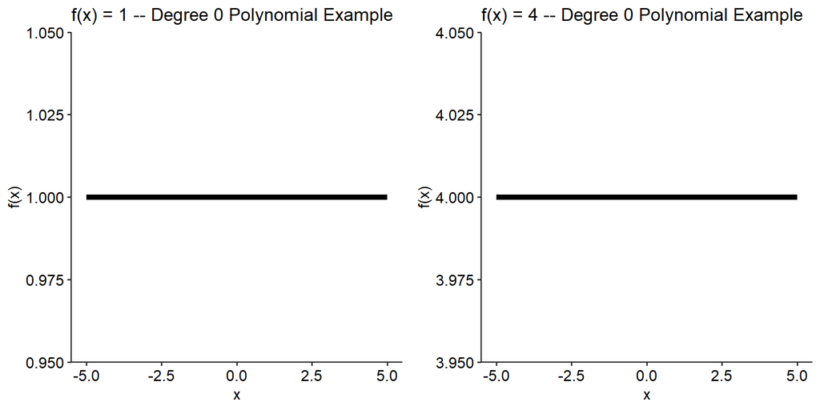

```r
ggarrange(
  ggplot(data.frame(x = 0), aes(x)) +
  stat_function(
    fun = function(x) 1,
    size = 2) +
  xlim(-5, 5) +
  theme_pubr() +
  ylab("f(x)") +
  ggtitle("f(x) = 1 -- Degree 0 Polynomial Example"),
  ggplot(data.frame(x = 0), aes(x)) +
  stat_function(
    fun = function(x) 4,
    size = 2) +
  xlim(-5, 5) +
  theme_pubr() +
  ylab("f(x)") +
  ggtitle("f(x) = 4 -- Degree 0 Polynomial Example"),
  ncol = 2)
```

## 5.2 Degree 1

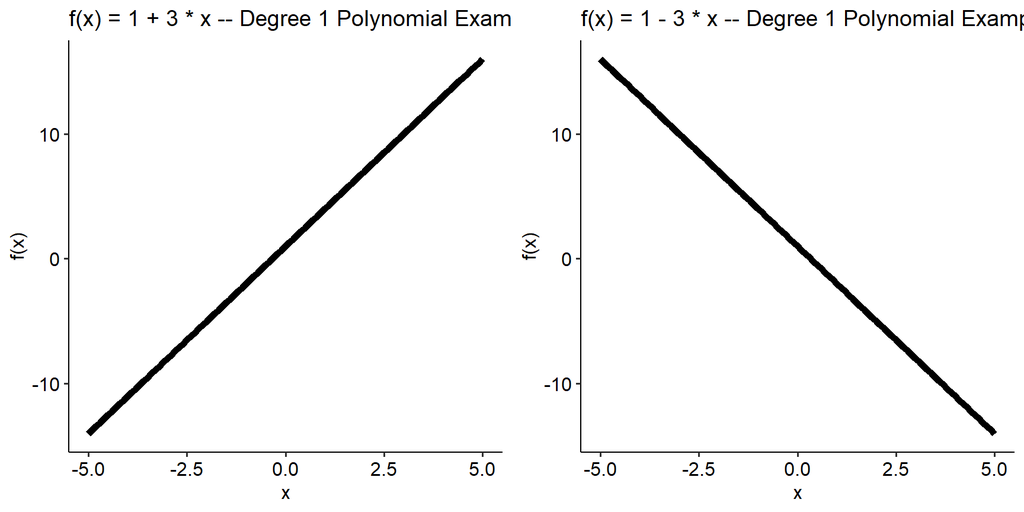

```r
ggarrange(
  ggplot(data.frame(x = 0), aes(x)) +
  stat_function(
    fun = function(x) 1 + 3 * x,
    size = 2) +
  xlim(-5, 5) +
  theme_pubr() +
  ylab("f(x)") +
  ggtitle("f(x) = 1 + 3 * x -- Degree 1 Polynomial Example"),
  ggplot(data.frame(x = 0), aes(x)) +
  stat_function(
    fun = function(x) 1 - 3 * x,
    size = 2) +
  xlim(-5, 5) +
  theme_pubr() +
  ylab("f(x)") +
  ggtitle("f(x) = 1 - 3 * x -- Degree 1 Polynomial Example"),
  ncol = 2)
```

## 5.3 Degree 2

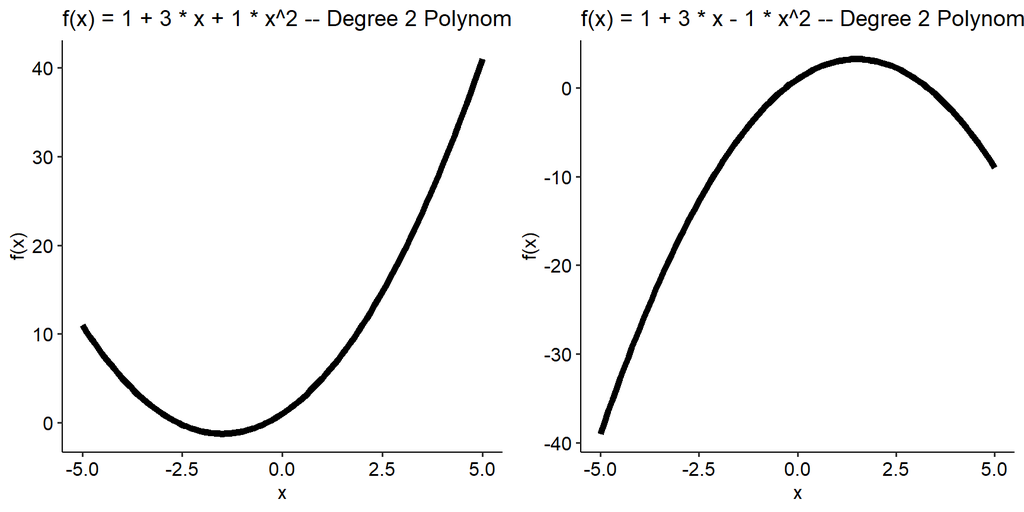

```r
ggarrange(
  ggplot(data.frame(x = 0), aes(x)) +
  stat_function(
    fun = function(x) 1 + 3 * x + 1 * x^2,
    size = 2) +
  xlim(-5, 5) +
  theme_pubr() +
  ylab("f(x)") +
  ggtitle("f(x) = 1 + 3 * x + 1 * x^2 -- Degree 2 Polynomial Example"),
  ggplot(data.frame(x = 0), aes(x)) +
  stat_function(
    fun = function(x) 1 + 3 * x - 1 * x^2,
    size = 2) +
  xlim(-5, 5) +
  theme_pubr() +
  ylab("f(x)") +
  ggtitle("f(x) = 1 + 3 * x - 1 * x^2 -- Degree 2 Polynomial Example"),
  ncol = 2)
```

## 5.4 Degree 3

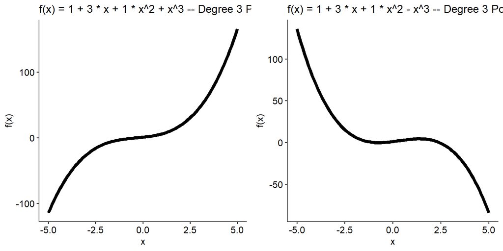

```r
ggarrange(
  ggplot(data.frame(x = 0), aes(x)) +
  stat_function(
    fun = function(x) 1 + 3 * x + 1 * x^2 + x^3,
    size = 2) +
  xlim(-5, 5) +
  theme_pubr() +
  ylab("f(x)") +
  ggtitle("f(x) = 1 + 3 * x + 1 * x^2 + x^3 -- Degree 3 Polynomial Example"),
  ggplot(data.frame(x = 0), aes(x)) +
  stat_function(
    fun = function(x) 1 + 3 * x + 1 * x^2 - x^3,
    size = 2) +
  xlim(-5, 5) +
  theme_pubr() +
  ylab("f(x)") +
  ggtitle("f(x) = 1 + 3 * x + 1 * x^2 - x^3 -- Degree 3 Polynomial Example"),
  ncol = 2)
```

Polynomials are a great, simple way to capture non-linear associations between a variable and an outcome and are commonly used in regression by including squared or cubed, etc. versions of a predictor, or using the `poly()` function in `R`.